# Test

Joshua Kock

11/10/2018

## Introducción:

Para el presente ejercicio utilizaremos datos de mamografia y cancer de seno disponibles libremente en https://www.kaggle.com/overratedgman/mammographic-mass-data-set, bajo la licencia de CC BY-NC-SA 4.0. Las pacientes fueron reclutados en el año 2007 midiendo variables relacionadas con la mamografia y posteriormente fueron sometidas a biopsia para definir la malignidad o no de los hallzagos imagenologico. Con los presentes datos realizaremos un modelo lineal generalizado logistico. La metodologia a implementar es:

1. La exploracion inicial de la base de datos y las variables.
2. La generacion de un Modelo lineal generalizado.
3. La simplificacion del model (si aplica).
4. El diagnostico del modelo.
5. Ajuste del modelo (si es necesario)
6. Conclusion.

En nuestro ejercicio vamos a establecer a *priori* como mi variable respuesta la presencia o no de malignidad en la biopsia de seno.

```r
ca_mama <- read.csv(here("data", "cancer_seno.csv"), header = TRUE)
```

## Exploración de base de datos.

Una vez cargada la base de datos exploramos su estructura con la función `str` “structure” y observamos que la base de datos contiene **5 variables** y **830 observaciones**. De igual manera procedo a cambiar el nombre de las variables al español con la función `names`.

```r
str(ca_mama)
```

```
## 'data.frame':    830 obs. of  5 variables:
##  $ Age     : int  67 58 28 57 76 42 36 60 54 52 ...
##  $ Shape   : int  3 4 1 1 1 2 3 2 1 3 ...
##  $ Margin  : int  5 5 1 5 4 1 1 1 1 4 ...
##  $ Density : int  3 3 3 3 3 3 2 2 3 3 ...
##  $ Severity: int  1 1 0 1 1 1 0 0 0 0 ...
```

```r
names(ca_mama) <- c("edad",
                    "forma",
                    "margen",
                    "dens",
                    "sev")
```

Una vez importada la base, hay que identificar si hay variables que faltan (datos perdidos), lo anterior lo hacemos con `is.na`, que hace parte del paquete **{base}**, en conjunto con la función de la familia `apply`. Con el resultado podemos concluir que no tenemos datos perdidos en mi data frame.

```r
sapply(ca_mama,function(x) sum(is.na(x)))
```

```
##   edad  forma margen   dens    sev
##      0      0      0      0      0
```

Histograma de edad de los pacientes en la base de datos

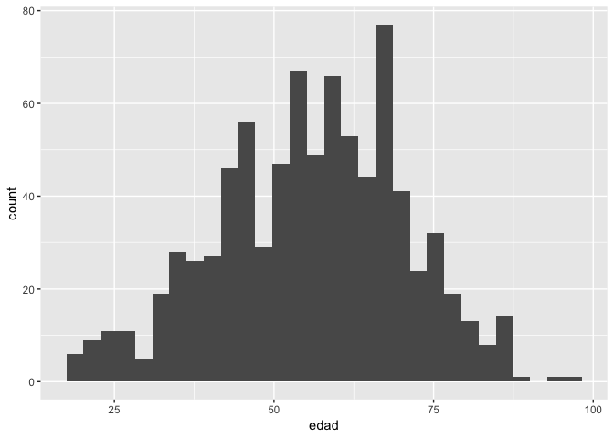

```r
ca_mama %>%
  ggplot(aes(edad)) +
  geom_histogram()
```